# Assignment 1

### MIS 64060: Fundamentals of Machine Learning

### Due Date: Sepetember 12th, 2021

**Questions 1 and 2:** *As the instructions indicated, I downloaded a datadet (biodataset) from the web for this assignment. The code that can be found below reads a .csv file (biodataset which was downloaded and imported into RStudio.) After the .csv file is read, the .csv file is assigned to the biodata variable. Once the .csv file is assigned to the biodata variable and the code is entered into RStudio (label assigned to the variable), the data for the .csv file will be printed. The source was specified in my code with the variable being given the name of biodata.*

```r
 biodata <- read.csv("biostats.csv")
 print(biodata)
```

```
##    Name        Sex Age Height Weight
## 1  Alex        "M"  41     74    170
## 2  Bert        "M"  42     68    166
## 3  Carl        "M"  32     70    155
## 4  Dave        "M"  39     72    167
## 5  Elly        "F"  30     66    124
## 6  Fran        "F"  33     66    115
## 7  Gwen        "F"  26     64    121
## 8  Hank        "M"  30     71    158
## 9  Ivan        "M"  53     72    175
## 10 Jake        "M"  32     69    143
## 11 Kate        "F"  47     69    139
## 12 Luke        "M"  34     72    163
## 13 Myra        "F"  23     62     98
## 14 Neil        "M"  36     75    160
## 15 Omar        "M"  38     70    145
## 16 Page        "F"  31     67    135
## 17 Quin        "M"  29     71    176
## 18 Ruth        "F"  28     65    131
```

**Question 3** *The code that can be found below prints out descriptive statics for a selection of quantitative and categorical variables. When the code is entered, the following quantitative: weight, age, and height and categorical: name, sex, and class are displayed.*

```r
 summary(biodata)
```

```
##      Name               Sex                 Age            Height
##  Length:18          Length:18          Min.   :23.00   Min.   :62.00
##  Class :character   Class :character   1st Qu.:30.00   1st Qu.:66.25
##  Mode  :character   Mode  :character   Median :32.50   Median :69.50
##                                        Mean   :34.67   Mean   :69.06
##                                        3rd Qu.:38.75   3rd Qu.:71.75
##                                        Max.   :53.00   Max.   :75.00
##      Weight
##  Min.   : 98.0
##  1st Qu.:132.0
##  Median :150.0
##  Mean   :146.7
##  3rd Qu.:165.2
##  Max.   :176.0
```

**Question 4** *The code that can be found below transforms one variable of the dataset. When the following code is used, the height variable is transformed as the height variable is no longer arranged in a random order. This is because once this code is entered (label assigned to the order variable ‘height’) , the height variable is now arranged in ascending order rather than in a random one.*

```r
 df <-biodata[order(biodata$Height),]
 df
```

```
##    Name        Sex Age Height Weight
## 13 Myra        "F"  23     62     98
## 7  Gwen        "F"  26     64    121
## 18 Ruth        "F"  28     65    131
## 5  Elly        "F"  30     66    124
## 6  Fran        "F"  33     66    115
## 16 Page        "F"  31     67    135
## 2  Bert        "M"  42     68    166
## 10 Jake        "M"  32     69    143
## 11 Kate        "F"  47     69    139
## 3  Carl        "M"  32     70    155
## 15 Omar        "M"  38     70    145
## 8  Hank        "M"  30     71    158
## 17 Quin        "M"  29     71    176
## 4  Dave        "M"  39     72    167
## 9  Ivan        "M"  53     72    175
## 12 Luke        "M"  34     72    163
## 1  Alex        "M"  41     74    170
## 14 Neil        "M"  36     75    160
```

**Question 5** *The code that can be found below plots at least one quantitative variable and one scatterplot. When the code is entered, a scatterplot is generated which plots age in correlation with an individual’s height. The height of a person is a quantitative variable of the dataset. Therefore, a quantitative variable was plotted in the scatterplot with the use of this code.*

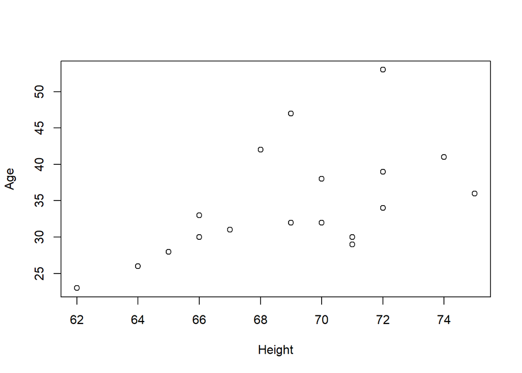

```r
 plot(biodata$Height,biodata$Age,xlab="Height",ylab="Age")
```

**Question 7** *I have copied and pasted my address to my repository in the assignment box located in Canvas as the instructions indicate for Assignment 1.*